# 06. Cronograma del Proyecto

El proyecto se estructura en una ejecución intensiva de 4 semanas (1 mes), diseñada para entregar resultados rápidos y de alto valor (Quick Wins).

**Fecha de Inicio:** 10 de Noviembre **Fecha de Finalización:** 10 de Diciembre

## Línea de Tiempo Detallada

### Semana 1: Planificación y Adquisición (Nov 10 - Nov 17)

- **Nov 10 - 12:** Reunión de inicio (Kick-off), definición de objetivos y alcance. Aprobación del uso de Datos Abiertos.
- **Nov 13 - 15:** Identificación y descarga de datasets (Cali y Envigado). Configuración del entorno de trabajo (GitHub).
- **Nov 16 - 17:** Revisión preliminar de la calidad de los datos.

### Semana 2: Ingeniería de Datos y EDA (Nov 18 - Nov 24)

- **Nov 18 - 20:** Desarrollo de scripts de limpieza (Manejo de nulos, estandarización).
- **Nov 21 - 23:** Ejecución del Análisis Exploratorio de Datos (EDA). Generación de estadísticas descriptivas.
- **Nov 24:** Primer reporte de hallazgos (Insights preliminares).

### Semana 3: Visualización y Desarrollo Web (Nov 25 - Dic 01)

- **Nov 25 - 27:** Diseño de mockups del Dashboard. Selección de gráficos clave.
- **Nov 28 - 30:** Implementación técnica del Dashboard (Generación de HTML/Gráficos interactivos).
- **Dic 01:** Pruebas de visualización y corrección de errores.

### Semana 4: Documentación y Cierre (Dic 02 - Dic 10)

- **Dic 02 - 05:** Redacción final de la Wiki (Descripción, Riesgos, Manuales).
- **Dic 06 - 08:** Revisión final de todos los entregables con el Líder del Proyecto.
- **Dic 09:** Despliegue final en GitHub Pages.
- **Dic 10:** Entrega oficial y presentación a Stakeholders.

## Diagrama de Gantt

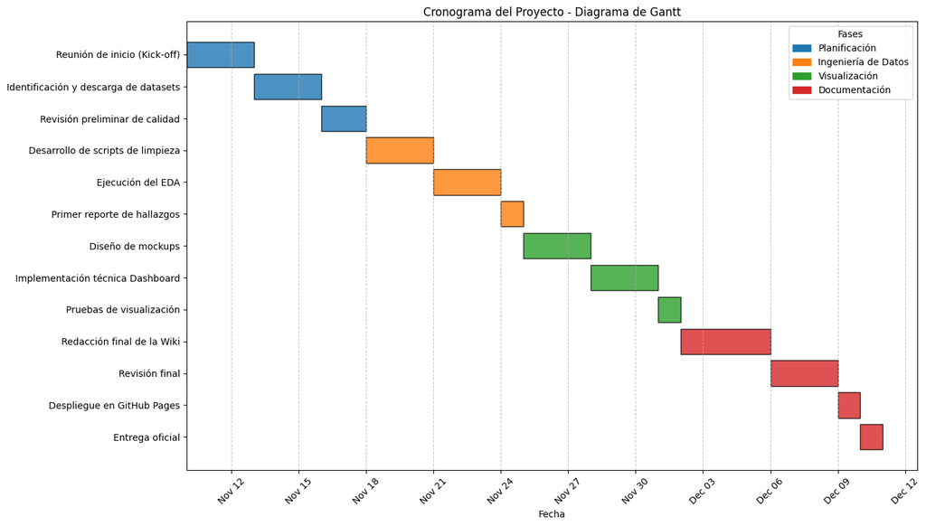

```python
import pandas as pd
import matplotlib.pyplot as plt
import matplotlib.dates as mdates

# Datos del cronograma
data = [
    {"Task": "Reunión de inicio (Kick-off)", "Start": "2025-11-10", "Finish": "2025-11-12", "Phase": "Planificación"},
    {"Task": "Identificación y descarga de datasets", "Start": "2025-11-13", "Finish": "2025-11-15", "Phase": "Planificación"},
    {"Task": "Revisión preliminar de calidad", "Start": "2025-11-16", "Finish": "2025-11-17", "Phase": "Planificación"},
    {"Task": "Desarrollo de scripts de limpieza", "Start": "2025-11-18", "Finish": "2025-11-20", "Phase": "Ingeniería de Datos"},
    {"Task": "Ejecución del EDA", "Start": "2025-11-21", "Finish": "2025-11-23", "Phase": "Ingeniería de Datos"},
    {"Task": "Primer reporte de hallazgos", "Start": "2025-11-24", "Finish": "2025-11-24", "Phase": "Ingeniería de Datos"},
    {"Task": "Diseño de mockups", "Start": "2025-11-25", "Finish": "2025-11-27", "Phase": "Visualización"},
    {"Task": "Implementación técnica Dashboard", "Start": "2025-11-28", "Finish": "2025-11-30", "Phase": "Visualización"},
    {"Task": "Pruebas de visualización", "Start": "2025-12-01", "Finish": "2025-12-01", "Phase": "Visualización"},
    {"Task": "Redacción final de la Wiki", "Start": "2025-12-02", "Finish": "2025-12-05", "Phase": "Documentación"},
    {"Task": "Revisión final", "Start": "2025-12-06", "Finish": "2025-12-08", "Phase": "Documentación"},
    {"Task": "Despliegue en GitHub Pages", "Start": "2025-12-09", "Finish": "2025-12-09", "Phase": "Documentación"},
    {"Task": "Entrega oficial", "Start": "2025-12-10", "Finish": "2025-12-10", "Phase": "Documentación"}
]

df = pd.DataFrame(data)
df['Start'] = pd.to_datetime(df['Start'])
df['Finish'] = pd.to_datetime(df['Finish'])
df['Duration'] = df['Finish'] - df['Start'] + pd.Timedelta(days=1)

# Colores por fase
colors = {
    "Planificación": "#1f77b4",
    "Ingeniería de Datos": "#ff7f0e",
    "Visualización": "#2ca02c",
    "Documentación": "#d62728"
}

fig, ax = plt.subplots(figsize=(14, 8))

# Invertir orden para que la primera tarea esté arriba
df = df.iloc[::-1]

# Crear barras
for i, task in df.iterrows():
    start = mdates.date2num(task['Start'])
    end = mdates.date2num(task['Finish'] + pd.Timedelta(days=1))
    duration = end - start

    ax.barh(task['Task'], duration, left=start, color=colors[task['Phase']], edgecolor='black', alpha=0.8)

# Formato del eje X
ax.xaxis.set_major_locator(mdates.DayLocator(interval=3))
ax.xaxis.set_major_formatter(mdates.DateFormatter('%b %d'))
plt.xticks(rotation=45)

# Etiquetas y Título
plt.xlabel("Fecha")
plt.title("Cronograma del Proyecto - Diagrama de Gantt")
plt.grid(axis='x', linestyle='--', alpha=0.7)

# Leyenda
handles = [plt.Rectangle((0,0),1,1, color=colors[label]) for label in colors]
plt.legend(handles, colors.keys(), title="Fases")

plt.tight_layout()
plt.show()
```